# Contract Classification: Schema 1 to Schema 2

- Show All Code
- Hide All Code
- View Source

Definitive reconciliation and overview

Author

Matthias Uckert and Ann-Kristin

Published

June 21, 2026

**TipHow to read this document**

This is a **working document** that doubles as a draft for the paper. Sections 1 and 2 (the classification logic and the old-to-new reconciliation) are written to be paper-ready. Section 3 (error diagnostics) is for our review only and would be dropped or condensed for the manuscript. Every number recomputes on render, so the prose stays in sync with the data on whichever machine runs it.

# 1 Classification logic

We classify each material contract into a single primary contract category, with an optional secondary category for documents that genuinely span two types, plus a binary amendment flag (Original / Amended). Two classification schemes exist: the original **Schema 1** used in the first submission, and the revised **Schema 2** introduced for this revision. The final label set reconciles the two.

## 1.1 Old scheme (Schema 1)

Schema 1 was produced by manual annotation through the `rLabelDocs` interface (stored in `Classifications.parquet`) and follows the categorisation of Verrecchia and Weber (2006) as described in the manuscript: seven broad categories resolving into ten specific contract types, plus the binary amendment flag.

```r
.s1_taxonomy <- tibble::tribble(
  ~Level1,                 ~Level2,
  "Employment",            "Compensation",
  "Employment",            "Legal",
  "Financial Instruments", "Debt",
  "Financial Instruments", "Equity",
  "Purchases Or Sales",    "Inventory or Services",
  "Purchases Or Sales",    "Assets",
  "Leases",                NA_character_,
  "License",               NA_character_,
  "M&A",                   NA_character_,
  "Other",                 NA_character_
)
.s1_taxonomy
```

| Level1 | Level2 |
| --- | --- |
| Employment | Compensation |
| Employment | Legal |
| Financial Instruments | Debt |
| Financial Instruments | Equity |
| Purchases Or Sales | Inventory or Services |
| Purchases Or Sales | Assets |
| Leases | NA |
| License | NA |
| M&A | NA |
| Other | NA |

## 1.2 New scheme (Schema 2)

In response to Reviewer 2, the scheme was revised to align with more recent literature (Boone et al. 2016; Bao et al. 2022, 2025, as cited in the project overview). Schema 2 sharpens category boundaries, splits two ambiguous categories, and adds previously missing types. It comprises twelve specific categories under seven Level-1 groups:

```r
.s2_taxonomy <- tibble::tribble(
  ~Level1,                  ~Level2,                 ~DocClass,
  "Financial Instruments",  "Credit",                "Financial Instruments: Credit",
  "Financial Instruments",  "Equity",                "Financial Instruments: Equity",
  "Leases",                 NA_character_,           "Leases",
  "Employment",             "Compensation",          "Employment: Compensation",
  "Employment",             "Legal",                 "Employment: Legal",
  "Purchases and Sales",    "Assets",                "Purchases and Sales: Assets",
  "Purchases and Sales",    "R&D",                   "R&D",
  "Purchases and Sales",    "Customer / Supplier",   "Customer / Supplier",
  "Licenses",               NA_character_,           "Licenses",
  "Other",                  NA_character_,           "Other",
  "Business Structure",     "Peer Agreements",       "Business Structure: Peer Agreements",
  "Business Structure",     "Investment and Merger", "Business Structure: Investment and Merger"
)
.s2_taxonomy
```

| Level1 | Level2 | DocClass |
| --- | --- | --- |
| Financial Instruments | Credit | Financial Instruments: Credit |
| Financial Instruments | Equity | Financial Instruments: Equity |
| Leases | NA | Leases |
| Employment | Compensation | Employment: Compensation |
| Employment | Legal | Employment: Legal |
| Purchases and Sales | Assets | Purchases and Sales: Assets |
| Purchases and Sales | R&D | R&D |
| Purchases and Sales | Customer / Supplier | Customer / Supplier |
| Licenses | NA | Licenses |
| Other | NA | Other |
| Business Structure | Peer Agreements | Business Structure: Peer Agreements |
| Business Structure | Investment and Merger | Business Structure: Investment and Merger |

The substantive changes from Schema 1 are: the old **Debt** category is renamed **Credit**; the old **Inventory or Services** category is split into **R&D** and **Customer / Supplier**; the old **M&A** category is split into **Business Structure: Peer Agreements** and **Business Structure: Investment and Merger**; and the remaining categories are unchanged or renamed only.

## 1.3 Combination rule

The two schemes are reconciled per document as follows (from the project overview, June 2026):

1. If a Schema-2 label exists for a document, **use it**.
2. Otherwise, if the document’s Schema-1 label belongs to a *name-change* or *unchanged* category, **map it forward** to its Schema-2 name.
3. Otherwise the Schema-1 label belongs to a *split* category (Inventory or Services, or M&A). These carry **no Schema-1 fallback** (“use S2 only”): the document is marked `UNRESOLVED` and requires a Schema-2 label. It is never carried forward under an outdated label.

The amendment flag (Original / Amended) is taken from Schema 1 only.

The forward map below is the operative version of this rule. Only name-change and unchanged rows are eligible for fallback; the split rows are listed for completeness but deliberately excluded from the map, which is what forces `UNRESOLVED`.

```r
.s1_s2_overview <- tibble::tribble(
  ~Schema1,                                  ~Transition,  ~Schema2,                                       ~Rule,
  "Fin. Instruments: Debt",                  "name change", "Financial Instruments: Credit",                "S2 if exists, else S1",
  "Fin. Instruments: Equity",                "unchanged",   "Financial Instruments: Equity",                "S2 if exists, else S1",
  "Empoyment: Compensation",                 "unchanged",   "Employment: Compensation",                     "S2 if exists, else S1",
  "Empoyment: Legal",                        "unchanged",   "Employment: Legal",                            "S2 if exists, else S1",
  "Leases: Leases Category",                 "name change", "Leases",                                       "S2 if exists, else S1",
  "License: License Category",               "name change", "Licenses",                                     "S2 if exists, else S1",
  "Other: Other Category",                   "name change", "Other",                                        "S2 if exists, else S1",
  "Purchases/Sales: Assets",                 "name change", "Purchases and Sales: Assets",                  "S2 if exists, else S1",
  "Purchases/Sales: Inventory or Services",  "split",       "R&D / Customer / Supplier",                    "S2 only -> UNRESOLVED if missing",
  "MergerAcquisition: M&A Category",         "split",       "Business Structure: Peer / Investment",        "S2 only -> UNRESOLVED if missing"
)
.s1_s2_overview
```

| Schema1 | Transition | Schema2 | Rule |
| --- | --- | --- | --- |
| Fin. Instruments: Debt | name change | Financial Instruments: Credit | S2 if exists, else S1 |
| Fin. Instruments: Equity | unchanged | Financial Instruments: Equity | S2 if exists, else S1 |
| Empoyment: Compensation | unchanged | Employment: Compensation | S2 if exists, else S1 |
| Empoyment: Legal | unchanged | Employment: Legal | S2 if exists, else S1 |
| Leases: Leases Category | name change | Leases | S2 if exists, else S1 |
| License: License Category | name change | Licenses | S2 if exists, else S1 |
| Other: Other Category | name change | Other | S2 if exists, else S1 |
| Purchases/Sales: Assets | name change | Purchases and Sales: Assets | S2 if exists, else S1 |
| Purchases/Sales: Inventory or Services | split | R&D / Customer / Supplier | S2 only -> UNRESOLVED if missing |
| MergerAcquisition: M&A Category | split | Business Structure: Peer / Investment | S2 only -> UNRESOLVED if missing |

Note the source typo “Empoyment” in the Schema-1 labels; it is preserved here because the map keys on the strings as they appear in the data.

```r
# Forward map actually used by the pipeline (name-change + unchanged only).
.s1_to_s2 <- tibble::tribble(
  ~DocClassS1,                  ~DocClass,
  "Purchases/Sales: Assets",    "Purchases and Sales: Assets",
  "Other: Other Category",      "Other",
  "License: License Category",  "Licenses",
  "Leases: Leases Category",    "Leases",
  "Fin. Instruments: Debt",     "Financial Instruments: Credit",
  "Fin. Instruments: Equity",   "Financial Instruments: Equity",
  "Empoyment: Compensation",    "Employment: Compensation",
  "Empoyment: Legal",           "Employment: Legal"
)

# Raw S2 label -> canonical. Accumulator for case / spacing / redundancy drift
# in what was typed in the labeling app; the validation check feeds this table.
.s2_relabel <- tibble::tribble(
  ~DocClassRaw,                                        ~DocClass,
  "Purchases and Sales: Purchases and Sales-Assets",   "Purchases and Sales: Assets",
  "Business structure: Investment and merger",         "Business Structure: Investment and Merger",
  "Business structure: Peer Agreements",               "Business Structure: Peer Agreements"
)
.s2_relabel
```

| DocClassRaw | DocClass |
| --- | --- |
| Purchases and Sales: Purchases and Sales-Assets | Purchases and Sales: Assets |
| Business structure: Investment and merger | Business Structure: Investment and Merger |
| Business structure: Peer Agreements | Business Structure: Peer Agreements |

# 2 Reconciliation (old to new)

```r
log_      <- cls_read_log(.path_db)
raw_s2_   <- cls_raw_s2_counts(log_)
s2_       <- cls_build_s2(log_, .s2_relabel)
s1_       <- cls_build_s1(.path_parq, .s1_to_s2)
final_    <- cls_combine(s2_, s1_, .s2_taxonomy)
checks_   <- cls_validate(final_, .s2_taxonomy, .s2_relabel, raw_s2_)
recon_    <- cls_reconcile_s1(log_, s1_)
selfdual_ <- cls_self_duals(log_)
coverage_ <- cls_coverage(s2_, s1_, final_)

kpi_ <- list(
  n_final    = nrow(final_),
  n_s2       = sum(final_$Provenance == "S2"),
  n_fb       = sum(final_$Provenance == "S1_fallback"),
  n_unres    = sum(final_$Provenance == "UNRESOLVED"),
  n_dual     = sum(final_$DualClass == 1L),
  n_orphan   = sum(is.na(final_$AmendType)),
  n_selfdual = nrow(selfdual_),
  n_disagree = sum(!recon_$Agree, na.rm = TRUE)
)
kpi_$pct_s2 <- round(100 * kpi_$n_s2 / kpi_$n_final, 1)
kpi_$pct_fb <- round(100 * kpi_$n_fb / kpi_$n_final, 1)
all_pass_   <- all(checks_$Status == "PASS")
```

```r
if (all_pass_) {
  cat("::: {.callout-note title='Validation: PASS'}\nAll structural checks passed (canonical label set, one row per document, no unmapped labels).\n:::\n")
} else {
  cat("::: {.callout-important title='Validation: FAIL'}\nA structural check failed -- see Section 3. A failure on the label-mapping check means a new raw label needs a row in `.s2_relabel`.\n:::\n")
}
```

**NoteValidation: PASS**

All structural checks passed (canonical label set, one row per document, no unmapped labels).

Of **4,402** documents, **1,058** (24%) carry a new Schema-2 label and **3,340** (75.9%) retain a Schema-1 label mapped forward; **4** remain unresolved. The Schema-2 re-labeling was therefore *targeted* at the split and changed categories rather than applied wall-to-wall, which is exactly what the “retain S1 where only S1 exists” rule prescribes (see Figure 4).

## 2.1 Source coverage

How the old (parquet) and new (log) document sets overlap. `n_s1_only` are documents that retain a mapped Schema-1 label; `n_s2_only` are documents present only in the new log (these have no amendment flag, see Section 3.2).

```r
coverage_
```

| n_s2 | n_s1 | n_both | n_s2_only | n_s1_only | n_final |
| --- | --- | --- | --- | --- | --- |
| 1058 | 4327 | 983 | 75 | 3344 | 4402 |

## 2.2 Provenance

Where each final label came from.

```r
final_ |> dplyr::count(Provenance)
```

| Provenance | n |
| --- | --- |
| S1_fallback | 3340 |
| S2 | 1058 |
| UNRESOLVED | 4 |

## 2.3 Forward map in action

Which Schema-1 labels actually fell back (no Schema-2 label existed), and the canonical category each was mapped to. This is the operative reconciliation.

```r
final_ |>
  dplyr::filter(Provenance == "S1_fallback") |>
  dplyr::count(DocClassS1, DocClassFinal1)
```

| DocClassS1 | DocClassFinal1 | n |
| --- | --- | --- |
| Empoyment: Compensation | Employment: Compensation | 659 |
| Empoyment: Legal | Employment: Legal | 703 |
| Fin. Instruments: Debt | Financial Instruments: Credit | 645 |
| Fin. Instruments: Equity | Financial Instruments: Equity | 268 |
| Leases: Leases Category | Leases | 295 |
| License: License Category | Licenses | 207 |
| Other: Other Category | Other | 274 |
| Purchases/Sales: Assets | Purchases and Sales: Assets | 289 |

## 2.4 S1 source reconciliation

The pipeline takes Schema-1 from the parquet. This check confirms that choice is safe by comparing it against the log’s own Schema-1 entries: `TRUE` where they agree, `FALSE` where they differ, `NA` where only one source has the document.

```r
recon_ |> dplyr::count(Agree)
```

| Agree | n |
| --- | --- |
| FALSE | 5 |
| TRUE | 4322 |
| NA | 1 |

Agreement is near-total; the 5 disagreements are detailed in Section 3.3.

# 3 Potential errors and mismatches

**WarningWorking-document section**

Each subsection below explains what the mismatch is, why it arises, whether it affects the final classification, and what (if anything) to do about it. These are diagnostics for our review and would not appear in the paper.

## 3.1 Unresolved documents

```r
final_ |>
  dplyr::filter(Provenance == "UNRESOLVED") |>
  dplyr::select(DocID, DocClassS1, AmendType)
```

| DocID | DocClassS1 | AmendType |
| --- | --- | --- |
| 0001046057-c1eeea97d12055f36d1aca71c959f209 | Purchases/Sales: Inventory or Services | Original |
| 0001069996-ab98e7c8375fdbca99f5a62e6ba0d7f3 | Purchases/Sales: Inventory or Services | Original |
| 0001120096-49b691c0c45cebcf9846bdacca35ccdd | Purchases/Sales: Inventory or Services | Original |
| 0001162324-10d55864d0e13d915719e546d0036c2d | Purchases/Sales: Inventory or Services | Original |

## 3.2 Documents missing from the old parquet

```r
final_ |>
  dplyr::filter(is.na(AmendType)) |>
  dplyr::count(DocClassFinal1)
```

| DocClassFinal1 | n |
| --- | --- |
| Business Structure: Investment and Merger | 3 |
| Business Structure: Peer Agreements | 3 |
| Customer / Supplier | 54 |
| Employment: Legal | 1 |
| Financial Instruments: Credit | 1 |
| Financial Instruments: Equity | 2 |
| Licenses | 7 |
| Purchases and Sales: Assets | 2 |
| R&D | 2 |

## 3.3 S1 source disagreements

These are documents where the old parquet and the new log hold **different** Schema-1 labels for the same document (`Agree == FALSE`), plus the one document that exists in only one source (`Agree == NA`). They occur because the parquet and the log were two separate labeling passes, and a few contracts – usually genuinely ambiguous ones, such as a document the parquet calls M&A and the log calls Equity – were labeled inconsistently between them. **None of them affect the final result.** Every one either carries a Schema-2 label (which overrides both old labels) or sits in a name-change category that resolves identically whichever source is used, and the pipeline takes Schema 1 from the parquet throughout. They are shown only as a transparency check on that source choice, and because they point to contracts whose type is genuinely contestable. Action: none required; optionally eyeball them to sanity-check the ambiguous cases.

```r
recon_ |> dplyr::filter(!Agree | is.na(Agree))
```

| DocID | S1_parq | S1_log | Agree |
| --- | --- | --- | --- |
| 0000099771-e22e3e77ea2aaf5dc246e1febf1977b1 | Empoyment: Compensation | Empoyment: Legal | FALSE |
| 0000354706-aa685283c08b39dbb0be09d795a05fde | MergerAcquisition: M&A Category | Empoyment: Compensation | FALSE |
| 0000356591-ad6b8a173265a530d95bcf3d128d0017 | MergerAcquisition: M&A Category | Fin. Instruments: Equity | FALSE |
| 0001045425-5b55cb628a8ec3b7215fdcb51d0df974 | Purchases/Sales: Assets | Other: Other Category | FALSE |
| 0001174922-d9b72c569cbfefd5c16a9b38a009c256 | MergerAcquisition: M&A Category | Purchases/Sales: Inventory or Services | FALSE |
| 0000062996-ca2d124cf57df28cbb719a4e16d002a8 | NA | Fin. Instruments: Debt | NA |

## 3.4 Dual-label hygiene

These are documents that were dual-classified with the **same** category in both slots, i.e. primary equals secondary (**1** document) – almost certainly a slip in the labeling interface where the category was picked twice. The pipeline collapses them back to a single label (it sets the secondary to `NA` in `cls_build_s2`), so they do **not** inflate the dual-classification counts or the multi-label population in Section 4. They are listed here only so they can be fixed at source if desired; no downstream action is required.

```r
selfdual_
```

| DocID | Value |
| --- | --- |
| 0000019252-782688622b5ae55e0f4c5a355f39066c | Business structure: Investment and merger |

## 3.5 Label drift handled

This lists every distinct raw Schema-2 label as it was typed in the labeling app, with how the pipeline handled it: `canonical` (already matches the taxonomy), `relabeled` (a case, spacing, or redundancy variant fixed via `.s2_relabel` – for example the lowercase `Business structure: ...` or the redundant `Purchases and Sales: Purchases and Sales-Assets`), or `UNKNOWN` (an unrecognised label). Drift happens because the app accepts the label more or less as free text, so the same category can be entered in slightly different forms. Relabeled variants are folded into their canonical name before any counting, and an `UNKNOWN` would fail the structural check in Section 2, flagging a new variant to add to `.s2_relabel`. One thing to note when reading the table: the counts include secondary (dual) labels and come from the Schema-2 log only, so they deliberately do **not** match the final category totals, which also include Schema-1 fallback. Action: if any row reads `UNKNOWN`, add it to `.s2_relabel` and re-render.

```r
raw_s2_ |>
  dplyr::mutate(
    Disposition = dplyr::case_when(
      Value %in% .s2_taxonomy$DocClass   ~ "canonical",
      Value %in% .s2_relabel$DocClassRaw ~ "relabeled",
      TRUE                               ~ "UNKNOWN"
    )
  ) |>
  dplyr::arrange(Disposition, dplyr::desc(n_raw))
```

| Value | n_raw | Disposition |
| --- | --- | --- |
| Customer / Supplier | 413 | canonical |
| R&D | 84 | canonical |
| Licenses | 75 | canonical |
| Other | 50 | canonical |
| Employment: Compensation | 43 | canonical |
| Financial Instruments: Equity | 38 | canonical |
| Financial Instruments: Credit | 31 | canonical |
| Employment: Legal | 28 | canonical |
| Leases | 15 | canonical |
| Business structure: Investment and merger | 306 | relabeled |
| Business structure: Peer Agreements | 74 | relabeled |
| Purchases and Sales: Purchases and Sales-Assets | 33 | relabeled |

# 4 Overviews

## 4.1 Distribution by hierarchy

The headline distribution, ready for a Table-1 view. The `NA` row (if any) is the unresolved documents.

```r
final_ |> dplyr::count(Level1, Level2, DocClassFinal1)
```

| Level1 | Level2 | DocClassFinal1 | n |
| --- | --- | --- | --- |
| Business Structure | Investment and Merger | Business Structure: Investment and Merger | 305 |
| Business Structure | Peer Agreements | Business Structure: Peer Agreements | 74 |
| Employment | Compensation | Employment: Compensation | 702 |
| Employment | Legal | Employment: Legal | 723 |
| Financial Instruments | Credit | Financial Instruments: Credit | 676 |
| Financial Instruments | Equity | Financial Instruments: Equity | 289 |
| Leases | NA | Leases | 300 |
| Licenses | NA | Licenses | 256 |
| Other | NA | Other | 311 |
| Purchases and Sales | Assets | Purchases and Sales: Assets | 313 |
| Purchases and Sales | Customer / Supplier | Customer / Supplier | 412 |
| Purchases and Sales | R&D | R&D | 37 |
| NA | NA | NA | 4 |

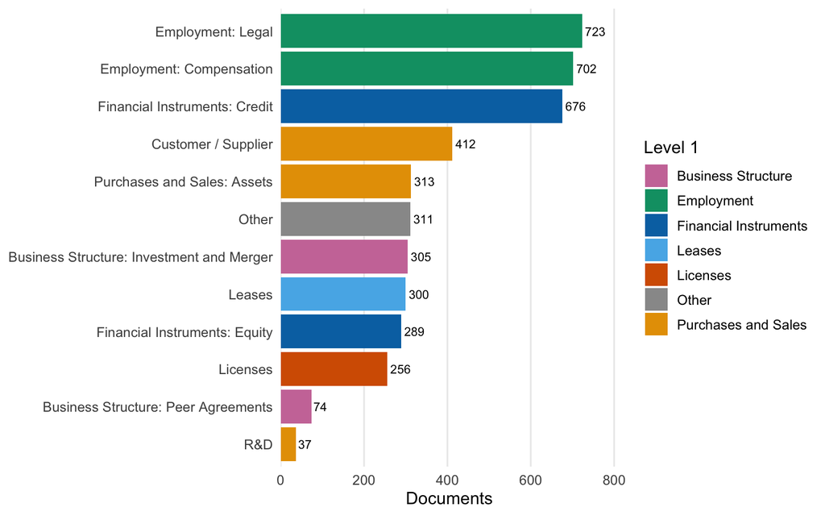

Figure 1: Distribution of contracts across the twelve Schema-2 categories, coloured by Level-1 group.

```r
cls_plot_distribution(final_)
```

## 4.2 Amendment flag

```r
final_ |> dplyr::count(AmendType)
```

| AmendType | n |
| --- | --- |
| Amended | 928 |
| Original | 3399 |
| NA | 75 |

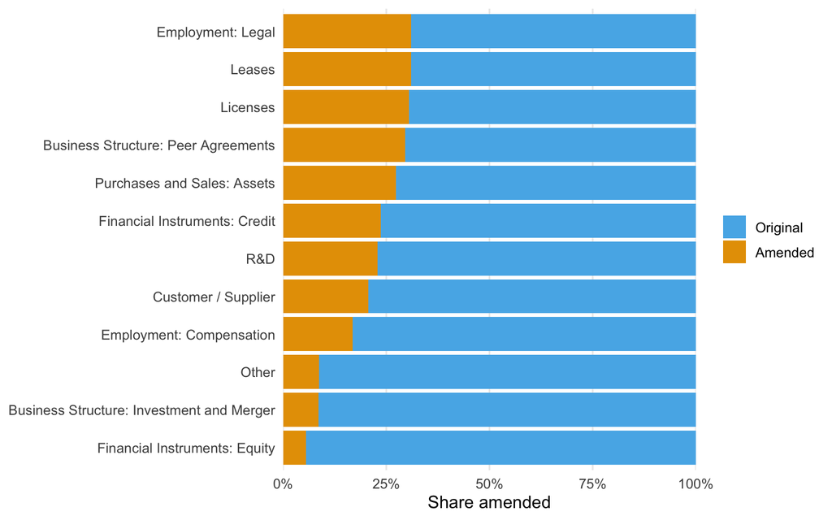

```r
cls_plot_amend(final_)
```

## 4.3 Dual classifications

The **131** documents with a genuine secondary category, and the primary / secondary pairs. This is the multi-label population relevant to Reviewer 2’s multi-label point.

```r
final_ |>
  dplyr::filter(DualClass == 1L) |>
  dplyr::count(DocClassFinal1, DocClassFinal2)
```

| DocClassFinal1 | DocClassFinal2 | n |
| --- | --- | --- |
| Business Structure: Investment and Merger | Customer / Supplier | 1 |
| Business Structure: Investment and Merger | Employment: Legal | 1 |
| Business Structure: Investment and Merger | Financial Instruments: Equity | 3 |
| Business Structure: Investment and Merger | Other | 2 |
| Business Structure: Investment and Merger | Purchases and Sales: Assets | 2 |
| Business Structure: Peer Agreements | Other | 2 |
| Business Structure: Peer Agreements | Purchases and Sales: Assets | 1 |
| Business Structure: Peer Agreements | R&D | 2 |
| Customer / Supplier | Employment: Legal | 6 |
| Customer / Supplier | Financial Instruments: Equity | 1 |
| Customer / Supplier | Leases | 4 |
| Customer / Supplier | Licenses | 25 |
| Customer / Supplier | Purchases and Sales: Assets | 1 |
| Customer / Supplier | R&D | 4 |
| Employment: Compensation | Employment: Legal | 1 |
| Employment: Compensation | Financial Instruments: Equity | 1 |
| Employment: Legal | Financial Instruments: Equity | 1 |
| Employment: Legal | Leases | 1 |
| Employment: Legal | Other | 4 |
| Financial Instruments: Credit | Financial Instruments: Equity | 11 |
| Financial Instruments: Credit | Leases | 4 |
| Financial Instruments: Credit | Other | 1 |
| Financial Instruments: Credit | Purchases and Sales: Assets | 1 |
| Financial Instruments: Equity | Leases | 1 |
| Financial Instruments: Equity | Other | 1 |
| Leases | Licenses | 1 |
| Leases | Purchases and Sales: Assets | 2 |
| Licenses | Other | 3 |
| Licenses | Purchases and Sales: Assets | 1 |
| Licenses | R&D | 40 |
| Other | Purchases and Sales: Assets | 1 |
| Other | R&D | 1 |

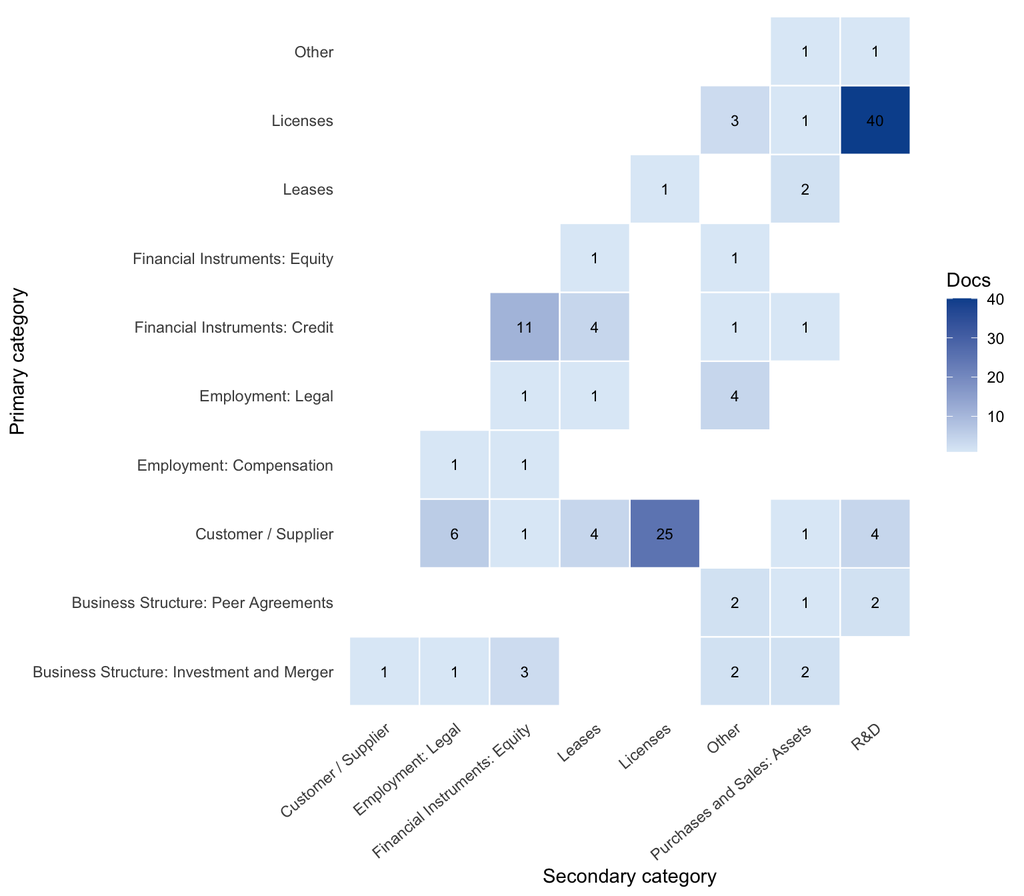

Figure 3: Co-occurrence of primary (rows) and secondary (columns) categories among dual-classified contracts.

```r
cls_plot_dual(final_)
```

## 4.4 Category by provenance

A cross-tab of how much of each final category comes from new Schema-2 work versus mapped Schema-1 labels.

```r
final_ |>
  dplyr::count(Level1, Provenance) |>
  tidyr::pivot_wider(names_from = Provenance, values_from = n, values_fill = 0L)
```

| Level1 | S2 | S1_fallback | UNRESOLVED |
| --- | --- | --- | --- |
| Business Structure | 379 | 0 | 0 |
| Employment | 63 | 1362 | 0 |
| Financial Instruments | 52 | 913 | 0 |
| Leases | 5 | 295 | 0 |
| Licenses | 49 | 207 | 0 |
| Other | 37 | 274 | 0 |
| Purchases and Sales | 473 | 289 | 0 |
| NA | 0 | 0 | 4 |

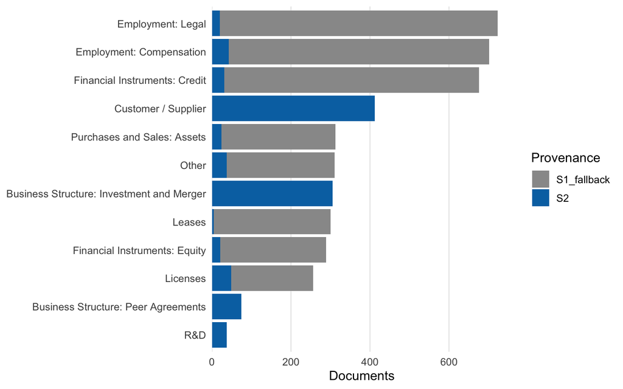

Figure 4: Provenance composition by category: new Schema-2 labels versus Schema-1 labels mapped forward. The Schema-2 re-labeling was targeted at the split and changed categories.

```r
cls_plot_provenance(final_)
```

## 4.5 Validation detail

```r
checks_
```

| Check | Status | Detail |
| --- | --- | --- |
| All final labels canonical (12 leaves) | PASS |  |
| One row per DocID | PASS |  |
| All raw S2 labels mapped (no UNKNOWN) | PASS |  |

# 5 Open decisions and next steps

1. **Schema-2 coverage is intentional.** Three-quarters of final labels are mapped Schema-1, by design of the “retain S1” rule. Confirm the paper text describes the sample’s provenance accordingly.
2. **Unresolved documents** (Section 3.1) need a per-document call.
3. **Documents added during the revision** (Section 3.2) – confirmed as deliberate additions, so the sample is now 4,402. The only open point is whether to backfill the amendment flag for these 75 documents or accept `NA`.
4. **Dual classifications** (Section 4.3) – decide how `DocClassFinal2` enters the analysis (multi-label, drop, or primary-only).
5. **S1 source** is settled in favour of the parquet (Section 2.4); the reconciliation section can be retired once we are both satisfied.
6. **Schema 3.** The log contains a third `DocClass` schema that is unused here. Confirm it is scratch.

# 6 Export

Disabled by default. Enable once the open decisions are settled.

```r
.path_out <- fs::path(dirname(.path_parq), "Classifications-Final-S2.parquet")
arrow::write_parquet(final_, .path_out)
haven::write_dta(final_, fs::path_ext_set(.path_out, "dta"))   # if Stata needs it
```